# dtree

## i was going to create a logisitcal regression but ended up creating a decision tree

```python
import pandas as pd
import re
import random
import os
import numpy as np
```

i need to create a dataset to train my logistical regression on

i want the following features:

- how many times appears the aliases
- proportion of alphanumeric char
- size of the text
- others ?

```python
df = pd.read_parquet("data02.parquet")
df.map(lambda x: len(x))
```

| companies | aliases | api.2000 | api.2003 | api.2006 | api.2009 | api.2012 | api.2015 | api.2018 |
| --- | --- | --- | --- | --- | --- | --- | --- | --- |
| Banco Comercial Português | 2 | 90 | 191 | 169 | 497 | 983 | 1219 | 824 |
| Galp Energia | 2 | 66 | 233 | 181 | 469 | 964 | 1104 | 812 |
| EDP | 3 | 80 | 245 | 140 | 538 | 1076 | 1528 | 872 |
| Sonae | 2 | 130 | 318 | 239 | 459 | 1109 | 1400 | 1026 |
| Mota-Engil | 2 | 3 | 67 | 26 | 164 | 384 | 596 | 445 |

```python
aliases = df.iloc[0,0]
texts = [i["ExtractedText"] for i in df.iloc[0,1]]
```

my features

```python
def count_alises(aliases, text):
    alias_count = {expression: 0 for expression in aliases}
    for alias in aliases:
        # Use re.escape to handle any special characters in the expression
        pattern = re.escape(alias.lower())
        matches = re.findall(pattern, text.lower())
        alias_count[alias] = len(matches)
    return sum(alias_count.values())

def proportion_alphanumeric(text):
    alphanumeric_chars = sum(char.isalnum() for char in text)
    proportion = alphanumeric_chars / len(text)
    return proportion

def count_dates(text):
    date_pattern = r'\b(\d{1,2}[-/]\d{1,2}[-/]\d{2,4}|\d{4}[-/]\d{1,2}[-/]\d{1,2})\b'
    # 10/11/2024', '10/10/2024', '12-25-1990', '2024-11-05', '01/10/2024'
    dates = re.findall(date_pattern, text)
    date_count = len(dates)
    return date_count

def count_CAPS(text):
    words = text.split()
    uppercase_word_count = sum(1 for word in words if word.isupper())
    return uppercase_word_count

def text_size(text):
    return len(text)

def Ist_ocurrence(text, aliases):
    indexs = []
    for alias in aliases:
        index = text.lower().find(alias.lower())
        if index != -1:
            indexs.append(index)
    return text[:min(indexs)].count(' ')

def count_HTTP(text):
    matches = re.findall("http", text.lower())
    return len(matches)

def count_time_occurrences(text):
    time_pattern = r'\b([01]?[0-9]|2[0-3]):[0-5][0-9]\b'
    occurrences = re.findall(time_pattern, text)
    return len(occurrences)
```

lets start creating the dataset

```python
def dataset_create(aliases, texts, out_name):
    dic = {"news": [], "countALI": [], "IstALIAS": [], "propAN": [], "countDTS": [], "txtSZ": [], "countCAPS": [], "txt": []}
    i = 0
    #global a
    random.shuffle(texts)
    for text in texts:
        valid = int(input(text))
        #valid = int(a[i])
        print(valid, end = ", ")
        if valid not in [0,1,-1,2]:
            print("not 0 or 1")
        elif valid == -1:
            i += 1
            break
        elif valid == 2:
            i += 1
            continue
        elif valid in [0,1]:
            dic["news"].append(valid)
            dic["txt"].append(text)
            dic["IstALIAS"].append(Ist_ocurrence(text, aliases))
            dic["countALI"].append(count_alises(aliases, text))
            dic["propAN"].append(proportion_alphanumeric(text))
            dic["countDTS"].append(count_dates(text))
            dic["txtSZ"].append(text_size(text))
            dic["countCAPS"].append(count_CAPS(text))
            # "countHOUR" = count_time_occurrences(text)
            # "countHTTP" = count_HTTP(text)
            i += 1
    pd.DataFrame(dic).to_csv(out_name)
    print(f"\n{i}")

# (0,2) (1,2) (3,4) (2,6) (1,6) (1,7) (3,3) (1,3) (4,1) (0,1) (4,6) (3,1) (1,4) (3,7)
line, year = 3, 7
aliases = df.iloc[line,0]
texts = [i["ExtractedText"] for i in df.iloc[line,year]]

#dataset_create(aliases, texts, "logreg_sonae2018.csv")
```

ao fazer merge dos csv:

- criar coluna com o ano e depois separar em até 2008, depois de 2009 até 2014, depois de 2015 aka 7 em 7 anos
  - associar isto à prop de alfanumericos, por causa da publicidade ?

acresencar features:

- DONE **titulo:** any alias in the first 50? char OU em q % de texto aparece o primeiro alias
- DONE **links:** quantidade de links externos, contar "http"
- DONE **horas:** quantidade de horas que aparecem "hh:mm"
- **fonte:** nos primeiros 50? caracteres ou nos finais, ver se diz rtp, publico, dn , etc. - vai ser variavel categorica, hot encoding
  - associar esta binaria ao tamanho do texto com multiplicacao
  - atencao q pode ter mais q rtp, publico no mesmo, pode se escolher o primeiro q aparecer
  - caso nao tenha nenhum, chamar unknokn
  - associar ao titulo, pq titulos sao diferentes consoante jornais

ideia:

e se fizer treedecision em vez de logistical regression ? CUIDADO COM OVERFITTING

merge all csvs

```python
"""
csvs = [(x, x[-8:-4]) for x in os.listdir() if x[:7] == "logreg_"]
dfs = []
for csv, year in csvs:
    df = pd.read_csv(csv, index_col=0)
    df["year"] = year
    dfs.append(df)
final_df = pd.concat(dfs, ignore_index=True)
"""
""
```

```
''
```

```python
"""





final_df["countHOUR"] = final_df["txt"].map(lambda x: count_time_occurrences(x))
final_df["countHTTP"] = final_df["txt"].map(lambda x: count_HTTP(x))

final_df
"""
""
```

```
''
```

```python
#final_df.to_csv("logreg.csv")
```

```python
#dataset = pd.read_csv("logreg.csv", index_col=0)
#dataset
```

convert year using hot encondig - bases on my observation creating the dataset and in the amount of news in each years group

- yearLow: 2000, 2003
- yearMed: 2006, 2009, 2012
- yearHig: 2015, 2018, 2020

```python
"""
dataset["yearLow"] = np.where(dataset["year"].isin([2000, 2003]), 1, 0)
dataset["yearMed"] = np.where(dataset["year"].isin([2006, 2009, 2012]), 1, 0)
dataset["yearHig"] = np.where(dataset["year"].isin([2015, 2018, 2020]), 1, 0)

#dataset.describe()
dataset.to_csv("DTreeData.csv")
"""
```

```
'\ndataset["yearLow"] = np.where(dataset["year"].isin([2000, 2003]), 1, 0)\ndataset["yearMed"] = np.where(dataset["year"].isin([2006, 2009, 2012]), 1, 0)\ndataset["yearHig"] = np.where(dataset["year"].isin([2015, 2018, 2020]), 1, 0)\n\n#dataset.describe()\ndataset.to_csv("DTreeData.csv")\n'
```

Logistic Regression works well when there is a linear relationship between features and the target variable. If your features have such a relationship, logistic regression would be a good choice.

Decision Trees, on the other hand, do not require linear relationships and can handle non-linear interactions between features. If there are complex, non-linear interactions in your data, a Decision Tree would likely perform better.

**maybe** a decision tree might be better for me since the relationships might not be linear

```python
from sklearn.tree import DecisionTreeClassifier, plot_tree
from sklearn.model_selection import train_test_split
from sklearn.metrics import accuracy_score, classification_report#, confusion_matrix
import matplotlib.pyplot as plt
from joblib import dump

dataset = pd.read_csv("dtree01.csv", index_col=0)
dataset
```

|  | news | countALI | propAN | countDTS | txtSZ | countCAPS | txt | IstALIAS | countHOUR | countHTTP | url | timestamp | date | alias_in_url | news_site | DTS+Hours |
| --- | --- | --- | --- | --- | --- | --- | --- | --- | --- | --- | --- | --- | --- | --- | --- | --- |
| 0 | 1 | 9 | 0.814786 | 0 | 5194 | 30 | PSD exige envolvimento da população de Matosin... | 12 | 2 | 1 | https://arquivo.pt/wayback/20110812205841/http... | 20110812205841 | 201108 | 1 | Público | 2 |
| 1 | 1 | 4 | 0.802270 | 0 | 3525 | 18 | Revista de imprensa de Ambiente de 4 de Maio -... | 211 | 1 | 1 | https://arquivo.pt/wayback/20100506155328/http... | 20100506155328 | 201005 | 0 | Público | 1 |
| 2 | 0 | 1 | 0.799427 | 1 | 3490 | 39 | DN - Diário de Notícias Última hora Bahrein:... | 213 | 1 | 0 | https://arquivo.pt/wayback/20110319062609/http... | 20110319062609 | 201103 | 0 | Diário de Notícias | 2 |
| 3 | 0 | 1 | 0.776351 | 1 | 5607 | 143 | Clube dos Portugueses - Antena 3 TV RTP 1 21... | 296 | 16 | 0 | https://arquivo.pt/wayback/20110524162024/http... | 20110524162024 | 201105 | 0 | RTP | 17 |
| 4 | 0 | 9 | 0.791497 | 5 | 15194 | 229 | À Noite, As Notícias TV RTP 1 23:08 CRIMINAL... | 262 | 15 | 0 | https://arquivo.pt/wayback/20110705151556/http... | 20110705151556 | 201107 | 0 | RTP | 20 |
| ... | ... | ... | ... | ... | ... | ... | ... | ... | ... | ... | ... | ... | ... | ... | ... | ... |
| 605 | 1 | 8 | 0.793415 | 17 | 1883 | 8 | rtp.pt 17/01/06 ENI continua com 33,34% da Gal... | 7 | 16 | 0 | https://arquivo.pt/wayback/20060117121252/http... | 20060117121252 | 200601 | 0 | RTP | 33 |
| 606 | 0 | 2 | 0.798363 | 25 | 5986 | 47 | RTP RTPVídeo \| Tempo \| Infografismo \| Trânsito... | 866 | 29 | 0 | https://arquivo.pt/wayback/20060904203923/http... | 20060904203923 | 200609 | 0 | RTP | 54 |
| 607 | 1 | 4 | 0.799881 | 0 | 5047 | 37 | DN-Suplementos Negócios 23 de Julho de 2001 Au... | 567 | 0 | 0 | https://arquivo.pt/wayback/20010725052410/http... | 20010725052410 | 200107 | 0 | Diário de Notícias | 0 |
| 608 | 0 | 2 | 0.794682 | 0 | 3234 | 34 | DN 20 de Setembro de 2001 Telecomunicações l... | 499 | 0 | 0 | https://arquivo.pt/wayback/20010920124822/http... | 20010920124822 | 200109 | 0 | Diário de Notícias | 0 |
| 609 | 0 | 1 | 0.643304 | 0 | 799 | 11 | Radiotelevisao Portuguesa RTPtexto 293-07 [ Pá... | 77 | 0 | 0 | https://arquivo.pt/wayback/20020628024219/http... | 20020628024219 | 200206 | 0 | RTP | 0 |

610 rows × 16 columns

```python
# features
#X = dataset[['countALI', 'propAN', 'countDTS', 'txtSZ', 'countCAPS', 'IstALIAS', 'countHOUR', 'countHTTP', 'yearLow', 'yearMed', 'yearHig']]
X = dataset[['countALI', 'propAN', 'countDTS', 'txtSZ', 'countCAPS', 'IstALIAS', 'countHOUR']]
X = dataset[['IstALIAS', 'propAN', 'txtSZ', 'countALI', 'countDTS', 'countHOUR', 'countCAPS']]

# target
y = dataset['news']

X_train, X_test, y_train, y_test = train_test_split(X, y, test_size=0.15, random_state=21)
```

```python
clf = DecisionTreeClassifier(random_state=21, max_depth=5, min_samples_split=15, min_samples_leaf=10) #3.2.2, 5.20.10
clf.fit(X_train, y_train)

y_pred = clf.predict(X_test)
print(f"Accuracy after tuning: {accuracy_score(y_test, y_pred)}")
print(f"Classification Report:\n {classification_report(y_test, y_pred)}")
```

```
Accuracy after tuning: 0.9130434782608695
Classification Report:
               precision    recall  f1-score   support

           0       0.92      0.97      0.94        68
           1       0.90      0.75      0.82        24

    accuracy                           0.91        92
   macro avg       0.91      0.86      0.88        92
weighted avg       0.91      0.91      0.91        92
```

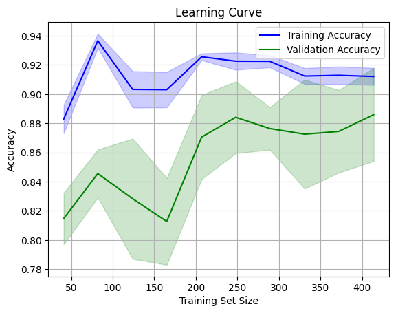

```python
from sklearn.model_selection import learning_curve

# Generating learning curve data
train_sizes, train_scores, test_scores = learning_curve(
    clf, X_train, y_train, cv=5, scoring='accuracy', n_jobs=-1,
    train_sizes=np.linspace(0.1, 1.0, 10)  # Vary the training set size from 10% to 100%
)


# Calculate mean and standard deviation of training and test scores
train_mean = np.mean(train_scores, axis=1)
train_std = np.std(train_scores, axis=1)
test_mean = np.mean(test_scores, axis=1)
test_std = np.std(test_scores, axis=1)


# Plot learning curves
plt.plot(train_sizes, train_mean, label="Training Accuracy", color="blue")
plt.plot(train_sizes, test_mean, label="Validation Accuracy", color="green")

# Plot shaded areas to represent the standard deviation of accuracy
plt.fill_between(train_sizes, train_mean - train_std, train_mean + train_std, color="blue", alpha=0.2)
plt.fill_between(train_sizes, test_mean - test_std, test_mean + test_std, color="green", alpha=0.2)

# Labels and title
plt.title("Learning Curve")
plt.xlabel("Training Set Size")
plt.ylabel("Accuracy")
plt.legend(loc="best")
plt.grid()

#plt.gcf().patch.set_alpha(0)
#plt.savefig('learning_curve.png', transparent=True, bbox_inches='tight', pad_inches=0.1)  # Save with transparent background

plt.show()
```

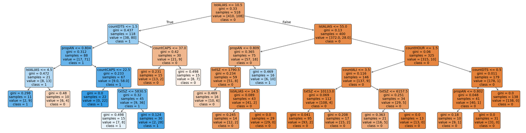

```python
plt.figure(figsize=(40, 10))
plot_tree(clf, filled=True, feature_names=X_train.columns, class_names=['0', '1'], rounded=True, fontsize=14)
#'Decision Tree Visualization'
#plt.gcf().patch.set_alpha(0)
#plt.savefig('decision_tree.png', transparent=True, bbox_inches='tight', pad_inches=0.1)
#plt.savefig('decision_tree.svg', transparent=True, bbox_inches='tight', pad_inches=0.1)

plt.show()
```

```python
# Assuming clf is your fitted DecisionTreeClassifier
# and X_test is your test dataset
probabilities = clf.predict_proba(X_test)

# Create a DataFrame to hold the probabilities
prob_df = pd.DataFrame(probabilities, columns=['Probability of Class 0', 'Probability of Class 1'])
prob_df

probabilities
```

```
array([[1.        , 0.        ],
       [1.        , 0.        ],
       [0.76190476, 0.23809524],
       [0.625     , 0.375     ],
       [0.97894737, 0.02105263],
       [0.76190476, 0.23809524],
       [1.        , 0.        ],
       [0.53333333, 0.46666667],
       [1.        , 0.        ],
       [1.        , 0.        ],
       [1.        , 0.        ],
       [0.625     , 0.375     ],
       [0.97894737, 0.02105263],
       [0.9       , 0.1       ],
       [0.        , 1.        ],
       [1.        , 0.        ],
       [1.        , 0.        ],
       [0.86666667, 0.13333333],
       [0.97894737, 0.02105263],
       [0.97894737, 0.02105263],
       [0.97894737, 0.02105263],
       [1.        , 0.        ],
       [0.18181818, 0.81818182],
       [1.        , 0.        ],
       [1.        , 0.        ],
       [1.        , 0.        ],
       [0.86666667, 0.13333333],
       [0.88235294, 0.11764706],
       [0.85714286, 0.14285714],
       [0.375     , 0.625     ],
       [0.        , 1.        ],
       [1.        , 0.        ],
       [1.        , 0.        ],
       [1.        , 0.        ],
       [1.        , 0.        ],
       [0.97894737, 0.02105263],
       [0.46666667, 0.53333333],
       [1.        , 0.        ],
       [1.        , 0.        ],
       [1.        , 0.        ],
```

[output cut: 37 more lines]

```
       [1.        , 0.        ],
       [0.86666667, 0.13333333],
       [0.        , 1.        ],
       [0.85714286, 0.14285714],
       [1.        , 0.        ],
       [0.97894737, 0.02105263],
       [0.76190476, 0.23809524],
       [0.18181818, 0.81818182],
       [0.        , 1.        ],
       [1.        , 0.        ],
       [1.        , 0.        ],
       [0.97894737, 0.02105263],
       [0.        , 1.        ],
       [0.06666667, 0.93333333],
       [1.        , 0.        ]])
```

```python
#dump(clf, 'dtree010000.joblib')
```

# APPLYNIG DECISION TREE TO THE REAL DATA

```python
data = pd.read_parquet("data02.parquet")
data = data[["aliases", "api.2000", "api.2003"]]
data
```

| companies | aliases | api.2000 | api.2003 |
| --- | --- | --- | --- |
| Banco Comercial Português | [Banco Comercial Português, BCP] | [{'ExtractedText': 'POL \| Economia \| Processo ... | [{'ExtractedText': 'RTP RTPVídeo \| Meteorologi... |
| Galp Energia | [Galp Energia, GALP] | [{'ExtractedText': 'DN-Suplementos Negócios 10... | [{'ExtractedText': 'RTP RTPVídeo \| Meteorologi... |
| EDP | [EDP, Energias de Portugal, Electricidade de P... | [{'ExtractedText': 'DN-Sinteses 19 de Maio de ... | [{'ExtractedText': 'DN 27 de Setembro de 200... |
| Sonae | [Sonae, SON] | [{'ExtractedText': 'Radiotelevisao Portuguesa ... | [{'ExtractedText': 'DN 27 de Setembro de 200... |
| Mota-Engil | [Mota-Engil, EGL] | [{'ExtractedText': 'DN-Suplementos Negócios 23... | [{'ExtractedText': 'RTP Empresas portuguesas s... |

```python
from joblib import load

# FEATURES
# [['IstALIAS', 'propAN', 'txtSZ', 'countALI', 'countDTS', 'countHOUR', 'countCAPS']]

# added "aliases" to all func in order to run them all without worrying about the inputs

def IstALIAS(text, aliases):
    """where does the first alias appear, title?"""
    indexs = []
    for alias in aliases:
        index = text.lower().find(alias.lower())
        if index != -1:
            indexs.append(index)
    return text[:min(indexs)].count(' ')

def propAN(text, aliases):
    """proportion of alphanumeric chars in the text"""
    alphanumeric_chars = sum(char.isalnum() for char in text)
    proportion = alphanumeric_chars / len(text)
    return proportion

def txtSZ(text, aliases):
    """text size"""
    return len(text)

def countALI(text, aliases):
    """count how many aliases appear in the text"""
    alias_count = {expression: 0 for expression in aliases}
    for alias in aliases:
        # Use re.escape to handle any special characters in the expression
        pattern = re.escape(alias.lower())
        matches = re.findall(pattern, text.lower())
        alias_count[alias] = len(matches)
    return sum(alias_count.values())

def countDTS(text, aliases):
    """count how many dates appear in the text"""
    date_pattern = r'\b(\d{1,2}[-/]\d{1,2}[-/]\d{2,4}|\d{4}[-/]\d{1,2}[-/]\d{1,2})\b'
    # 10/11/2024', '10/10/2024', '12-25-1990', '2024-11-05', '01/10/2024'
    dates = re.findall(date_pattern, text)
    date_count = len(dates)
    return date_count

def countHOUR(text, aliases):
    """count how many hours (ex.: hh:mm) appear in the text"""
    time_pattern = r'\b([01]?[0-9]|2[0-3]):[0-5][0-9]\b'
    occurrences = re.findall(time_pattern, text)
    return len(occurrences)

def countCAPS(text, aliases):
    """count how many WORDS are upper"""
    words = text.split()
    uppercase_word_count = sum(1 for word in words if word.isupper())
    return uppercase_word_count

# Load the saved model
clf = load('dtree01.joblib')
```

```python
features = ['IstALIAS', 'propAN', 'txtSZ', 'countALI', 'countDTS', 'countHOUR', 'countCAPS']

data = pd.read_parquet("data02.parquet")

"""
for row in data.index:
    print(f"\n {row}", end = ": ")
    aliases = data.loc[row, "aliases"]
    for column in data.columns[1:]:
        print(column, end = " | ")
        ones = []
        for req in data.loc[row, column]:
            text = req["ExtractedText"]
            df = {}
            for feature in features:
                df[feature] = [globals()[feature](text, aliases)]
            prediction = clf.predict(pd.DataFrame(df))
            if prediction == 0:
                pass
            else:
                ones.append(req)
            #data.iloc[-1,1] = ones
        data.loc[row, column] = ones
"""
""
```

```
''
```

```python
data.map(lambda x: len(x)) - pd.read_parquet("data02.parquet").map(lambda x: len(x))
```

| companies | aliases | api.2000 | api.2003 | api.2006 | api.2009 | api.2012 | api.2015 | api.2018 |
| --- | --- | --- | --- | --- | --- | --- | --- | --- |
| Banco Comercial Português | 0 | 0 | 0 | 0 | 0 | 0 | 0 | 0 |
| Galp Energia | 0 | 0 | 0 | 0 | 0 | 0 | 0 | 0 |
| EDP | 0 | 0 | 0 | 0 | 0 | 0 | 0 | 0 |
| Sonae | 0 | 0 | 0 | 0 | 0 | 0 | 0 | 0 |
| Mota-Engil | 0 | 0 | 0 | 0 | 0 | 0 | 0 | 0 |

```python
data.map(lambda x: len(x))
```

| companies | aliases | api.2000 | api.2003 | api.2006 | api.2009 | api.2012 | api.2015 | api.2018 |
| --- | --- | --- | --- | --- | --- | --- | --- | --- |
| Banco Comercial Português | 2 | 90 | 191 | 169 | 497 | 983 | 1219 | 824 |
| Galp Energia | 2 | 66 | 233 | 181 | 469 | 964 | 1104 | 812 |
| EDP | 3 | 80 | 245 | 140 | 538 | 1076 | 1528 | 872 |
| Sonae | 2 | 130 | 318 | 239 | 459 | 1109 | 1400 | 1026 |
| Mota-Engil | 2 | 3 | 67 | 26 | 164 | 384 | 596 | 445 |

```python
data.iloc[3,5]
```

```
array([{'ExtractedText': 'Sonae está preparada para avançar para Angola - Economia - DN Início Política Desporto Cartaz Gente Especiais Galerias Arquivo 19-01-2012 \xa0|\xa0 \xa0|\xa0 \xa0|\xa0 login DN Mobile | Iniciativas DN | Assine o DN | Classificados | Loja do Jornal Portugal Globo Economia Ci…
       {'ExtractedText': 'Sonae está preparada para avançar para Angola - Economia - DN Início Política Desporto Cartaz Gente Especiais Galerias Arquivo 20-01-2012 \xa0|\xa0 \xa0|\xa0 \xa0|\xa0 login DN Mobile | Iniciativas DN | Assine o DN | Classificados | Loja do Jornal Portugal Globo Economia Ci…
       {'ExtractedText': 'Sonae Indústria fechou 2011 com resultado negativo - Economia - DN Início Política Desporto Cartaz Gente Especiais Galerias Arquivo 02-03-2012 \xa0|\xa0 \xa0|\xa0 \xa0|\xa0 login DN Mobile | Iniciativas DN | Assine o DN | Classificados | Loja do Jornal Portugal Globo Econom…
       ...,
       {'ExtractedText': '“O império português é talvez o mais flexível a gerir populações coloniais até ao século XVIII” - PÚBLICO Entrevista “O império português é talvez o mais flexível a gerir populações coloniais até ao século XVIII” Por Isabel Salema (em Londres) 27/06/2014 - 08:04 Francisco B…
       {'ExtractedText': '“O império português é talvez o mais flexível a gerir populações coloniais até ao século XVIII” - PÚBLICO Entrevista “O império português é talvez o mais flexível a gerir populações coloniais até ao século XVIII” Por Isabel Salema (em Londres) 27/06/2014 - 08:04 Francisco B…
       {'ExtractedText': '“O império português é talvez o mais flexível a gerir populações coloniais até ao século XVIII” - PÚBLICO Entrevista “O império português é talvez o mais flexível a gerir populações coloniais até ao século XVIII” Por Isabel Salema (em Londres) 27/06/2014 - 08:04 Francisco B…
      dtype=object)
```

## talvez seja boa ideia treinar o modelo para ler também o link da noticia e a publicadora da noticia?

```python
data = pd.read_parquet("data02.parquet")
lista = []
for j in [0,1,2,3,4]:
    for i in data.iloc[j, 1:]:
        lista.extend(i)
len(lista)
```

```
18647
```

```python
tee = pd.read_csv("dtree01.csv", index_col=0)
#tee = tee.drop(['year', 'yearMed', "yearHig", "yearLow"], axis=1)
tee
```

|  | news | countALI | propAN | countDTS | txtSZ | countCAPS | txt | IstALIAS | countHOUR | countHTTP | url | timestamp | date | alias_in_url | news_site | DTS+Hours |
| --- | --- | --- | --- | --- | --- | --- | --- | --- | --- | --- | --- | --- | --- | --- | --- | --- |
| 0 | 1 | 9 | 0.814786 | 0 | 5194 | 30 | PSD exige envolvimento da população de Matosin... | 12 | 2 | 1 | https://arquivo.pt/wayback/20110812205841/http... | 20110812205841 | 201108 | 1 | Público | 2 |
| 1 | 1 | 4 | 0.802270 | 0 | 3525 | 18 | Revista de imprensa de Ambiente de 4 de Maio -... | 211 | 1 | 1 | https://arquivo.pt/wayback/20100506155328/http... | 20100506155328 | 201005 | 0 | Público | 1 |
| 2 | 0 | 1 | 0.799427 | 1 | 3490 | 39 | DN - Diário de Notícias Última hora Bahrein:... | 213 | 1 | 0 | https://arquivo.pt/wayback/20110319062609/http... | 20110319062609 | 201103 | 0 | Diário de Notícias | 2 |
| 3 | 0 | 1 | 0.776351 | 1 | 5607 | 143 | Clube dos Portugueses - Antena 3 TV RTP 1 21... | 296 | 16 | 0 | https://arquivo.pt/wayback/20110524162024/http... | 20110524162024 | 201105 | 0 | RTP | 17 |
| 4 | 0 | 9 | 0.791497 | 5 | 15194 | 229 | À Noite, As Notícias TV RTP 1 23:08 CRIMINAL... | 262 | 15 | 0 | https://arquivo.pt/wayback/20110705151556/http... | 20110705151556 | 201107 | 0 | RTP | 20 |
| ... | ... | ... | ... | ... | ... | ... | ... | ... | ... | ... | ... | ... | ... | ... | ... | ... |
| 605 | 1 | 8 | 0.793415 | 17 | 1883 | 8 | rtp.pt 17/01/06 ENI continua com 33,34% da Gal... | 7 | 16 | 0 | https://arquivo.pt/wayback/20060117121252/http... | 20060117121252 | 200601 | 0 | RTP | 33 |
| 606 | 0 | 2 | 0.798363 | 25 | 5986 | 47 | RTP RTPVídeo \| Tempo \| Infografismo \| Trânsito... | 866 | 29 | 0 | https://arquivo.pt/wayback/20060904203923/http... | 20060904203923 | 200609 | 0 | RTP | 54 |
| 607 | 1 | 4 | 0.799881 | 0 | 5047 | 37 | DN-Suplementos Negócios 23 de Julho de 2001 Au... | 567 | 0 | 0 | https://arquivo.pt/wayback/20010725052410/http... | 20010725052410 | 200107 | 0 | Diário de Notícias | 0 |
| 608 | 0 | 2 | 0.794682 | 0 | 3234 | 34 | DN 20 de Setembro de 2001 Telecomunicações l... | 499 | 0 | 0 | https://arquivo.pt/wayback/20010920124822/http... | 20010920124822 | 200109 | 0 | Diário de Notícias | 0 |
| 609 | 0 | 1 | 0.643304 | 0 | 799 | 11 | Radiotelevisao Portuguesa RTPtexto 293-07 [ Pá... | 77 | 0 | 0 | https://arquivo.pt/wayback/20020628024219/http... | 20020628024219 | 200206 | 0 | RTP | 0 |

610 rows × 16 columns

```python
timestamp = []
url = []
a = 1
for texto in tee["txt"]:
    a+=1
    for req in lista:
        if req["ExtractedText"] == texto:
            timestamp.append(req["tstamp"])
            url.append(req["linkToArchive"])
            break
tee["url"] = url
tee["timestamp"] = timestamp
```

```python
tee
```

|  | news | countALI | propAN | countDTS | txtSZ | countCAPS | txt | IstALIAS | countHOUR | countHTTP | url | timestamp | date | alias_in_url | news_site | DTS+Hours |
| --- | --- | --- | --- | --- | --- | --- | --- | --- | --- | --- | --- | --- | --- | --- | --- | --- |
| 0 | 1 | 9 | 0.814786 | 0 | 5194 | 30 | PSD exige envolvimento da população de Matosin... | 12 | 2 | 1 | https://arquivo.pt/wayback/20110812205841/http... | 20110812205841 | 201108 | 1 | Público | 2 |
| 1 | 1 | 4 | 0.802270 | 0 | 3525 | 18 | Revista de imprensa de Ambiente de 4 de Maio -... | 211 | 1 | 1 | https://arquivo.pt/wayback/20100506155328/http... | 20100506155328 | 201005 | 0 | Público | 1 |
| 2 | 0 | 1 | 0.799427 | 1 | 3490 | 39 | DN - Diário de Notícias Última hora Bahrein:... | 213 | 1 | 0 | https://arquivo.pt/wayback/20110319062609/http... | 20110319062609 | 201103 | 0 | Diário de Notícias | 2 |
| 3 | 0 | 1 | 0.776351 | 1 | 5607 | 143 | Clube dos Portugueses - Antena 3 TV RTP 1 21... | 296 | 16 | 0 | https://arquivo.pt/wayback/20110524162024/http... | 20110524162024 | 201105 | 0 | RTP | 17 |
| 4 | 0 | 9 | 0.791497 | 5 | 15194 | 229 | À Noite, As Notícias TV RTP 1 23:08 CRIMINAL... | 262 | 15 | 0 | https://arquivo.pt/wayback/20110705151556/http... | 20110705151556 | 201107 | 0 | RTP | 20 |
| ... | ... | ... | ... | ... | ... | ... | ... | ... | ... | ... | ... | ... | ... | ... | ... | ... |
| 605 | 1 | 8 | 0.793415 | 17 | 1883 | 8 | rtp.pt 17/01/06 ENI continua com 33,34% da Gal... | 7 | 16 | 0 | https://arquivo.pt/wayback/20060117121252/http... | 20060117121252 | 200601 | 0 | RTP | 33 |
| 606 | 0 | 2 | 0.798363 | 25 | 5986 | 47 | RTP RTPVídeo \| Tempo \| Infografismo \| Trânsito... | 866 | 29 | 0 | https://arquivo.pt/wayback/20060904203923/http... | 20060904203923 | 200609 | 0 | RTP | 54 |
| 607 | 1 | 4 | 0.799881 | 0 | 5047 | 37 | DN-Suplementos Negócios 23 de Julho de 2001 Au... | 567 | 0 | 0 | https://arquivo.pt/wayback/20010725052410/http... | 20010725052410 | 200107 | 0 | Diário de Notícias | 0 |
| 608 | 0 | 2 | 0.794682 | 0 | 3234 | 34 | DN 20 de Setembro de 2001 Telecomunicações l... | 499 | 0 | 0 | https://arquivo.pt/wayback/20010920124822/http... | 20010920124822 | 200109 | 0 | Diário de Notícias | 0 |
| 609 | 0 | 1 | 0.643304 | 0 | 799 | 11 | Radiotelevisao Portuguesa RTPtexto 293-07 [ Pá... | 77 | 0 | 0 | https://arquivo.pt/wayback/20020628024219/http... | 20020628024219 | 200206 | 0 | RTP | 0 |

610 rows × 16 columns

```python
tee["date"] = tee["timestamp"].str[:6].astype(int)
```

```python
tee.dtypes
```

```
news              int64
countALI          int64
propAN          float64
countDTS          int64
txtSZ             int64
countCAPS         int64
txt              object
IstALIAS          int64
countHOUR         int64
countHTTP         int64
url              object
timestamp        object
date              int64
alias_in_url      int64
news_site        object
DTS+Hours         int64
dtype: object
```

nao consigo saber de onde veio cada texto para saber do alias correspondente, entao vou aldrabar, nao deve fazer mal em principio...

tambem quero saber a origem da noticia tendo em conta o link

```python
news = pd.read_csv("noticias.csv", header=None)
#news
```

```python
alias_in_url = []
news_site = []
for index, row in tee.iterrows():
    url = row["url"]
    for inde, ro in news.iterrows():
        if ro[0] in url:
            news_site.append(ro[1])
            break
    al = False
    for alias in ["galp", "edp", "energias-de-portugal", "mota-engil", "banco-comercial-portugues", "bcp", "sonae"]:
        if alias in url:
            alias_in_url.append(1)
            al = True
            break
    if not al:
        alias_in_url.append(0)

tee["alias_in_url"] = alias_in_url
tee["news_site"] = news_site
tee
```

|  | news | countALI | propAN | countDTS | txtSZ | countCAPS | txt | IstALIAS | countHOUR | countHTTP | url | timestamp | date | alias_in_url | news_site | DTS+Hours |
| --- | --- | --- | --- | --- | --- | --- | --- | --- | --- | --- | --- | --- | --- | --- | --- | --- |
| 0 | 1 | 9 | 0.814786 | 0 | 5194 | 30 | PSD exige envolvimento da população de Matosin... | 12 | 2 | 1 | https://arquivo.pt/wayback/20110812205841/http... | 20110812205841 | 201108 | 1 | Público | 2 |
| 1 | 1 | 4 | 0.802270 | 0 | 3525 | 18 | Revista de imprensa de Ambiente de 4 de Maio -... | 211 | 1 | 1 | https://arquivo.pt/wayback/20100506155328/http... | 20100506155328 | 201005 | 0 | Público | 1 |
| 2 | 0 | 1 | 0.799427 | 1 | 3490 | 39 | DN - Diário de Notícias Última hora Bahrein:... | 213 | 1 | 0 | https://arquivo.pt/wayback/20110319062609/http... | 20110319062609 | 201103 | 0 | Diário de Notícias | 2 |
| 3 | 0 | 1 | 0.776351 | 1 | 5607 | 143 | Clube dos Portugueses - Antena 3 TV RTP 1 21... | 296 | 16 | 0 | https://arquivo.pt/wayback/20110524162024/http... | 20110524162024 | 201105 | 0 | RTP | 17 |
| 4 | 0 | 9 | 0.791497 | 5 | 15194 | 229 | À Noite, As Notícias TV RTP 1 23:08 CRIMINAL... | 262 | 15 | 0 | https://arquivo.pt/wayback/20110705151556/http... | 20110705151556 | 201107 | 0 | RTP | 20 |
| ... | ... | ... | ... | ... | ... | ... | ... | ... | ... | ... | ... | ... | ... | ... | ... | ... |
| 605 | 1 | 8 | 0.793415 | 17 | 1883 | 8 | rtp.pt 17/01/06 ENI continua com 33,34% da Gal... | 7 | 16 | 0 | https://arquivo.pt/wayback/20060117121252/http... | 20060117121252 | 200601 | 0 | RTP | 33 |
| 606 | 0 | 2 | 0.798363 | 25 | 5986 | 47 | RTP RTPVídeo \| Tempo \| Infografismo \| Trânsito... | 866 | 29 | 0 | https://arquivo.pt/wayback/20060904203923/http... | 20060904203923 | 200609 | 0 | RTP | 54 |
| 607 | 1 | 4 | 0.799881 | 0 | 5047 | 37 | DN-Suplementos Negócios 23 de Julho de 2001 Au... | 567 | 0 | 0 | https://arquivo.pt/wayback/20010725052410/http... | 20010725052410 | 200107 | 0 | Diário de Notícias | 0 |
| 608 | 0 | 2 | 0.794682 | 0 | 3234 | 34 | DN 20 de Setembro de 2001 Telecomunicações l... | 499 | 0 | 0 | https://arquivo.pt/wayback/20010920124822/http... | 20010920124822 | 200109 | 0 | Diário de Notícias | 0 |
| 609 | 0 | 1 | 0.643304 | 0 | 799 | 11 | Radiotelevisao Portuguesa RTPtexto 293-07 [ Pá... | 77 | 0 | 0 | https://arquivo.pt/wayback/20020628024219/http... | 20020628024219 | 200206 | 0 | RTP | 0 |

610 rows × 16 columns

```python
tee["DTS+Hours"] = tee["countDTS"] + tee["countHOUR"]
```

```python
#tee.to_csv("dtree02.csv")
```

```python
# Clear all variables in Jupyter Notebook
%reset -f
```

```python
import pandas as pd
import re
import random
import os
import numpy as np
```

```python
dataset = pd.read_csv("dtree01.csv", index_col=0)
dataset.info()
```

```
<class 'pandas.core.frame.DataFrame'>
Index: 610 entries, 0 to 609
Data columns (total 16 columns):
 #   Column        Non-Null Count  Dtype
---  ------        --------------  -----
 0   news          610 non-null    int64
 1   countALI      610 non-null    int64
 2   propAN        610 non-null    float64
 3   countDTS      610 non-null    int64
 4   txtSZ         610 non-null    int64
 5   countCAPS     610 non-null    int64
 6   txt           610 non-null    object
 7   IstALIAS      610 non-null    int64
 8   countHOUR     610 non-null    int64
 9   countHTTP     610 non-null    int64
 10  url           610 non-null    object
 11  timestamp     610 non-null    int64
 12  date          610 non-null    int64
 13  alias_in_url  610 non-null    int64
 14  news_site     610 non-null    object
 15  DTS+Hours     610 non-null    int64
dtypes: float64(1), int64(12), object(3)
memory usage: 81.0+ KB
```

```python
from sklearn.tree import DecisionTreeClassifier, plot_tree
from sklearn.model_selection import train_test_split
from sklearn.metrics import accuracy_score, classification_report#, confusion_matrix
import matplotlib.pyplot as plt
from joblib import dump

##

state = 124348

# features
X = dataset[['countALI', 'propAN', 'countDTS', 'txtSZ', 'countCAPS', 'IstALIAS', 'countHOUR',
             'countHTTP', 'date', 'alias_in_url', "DTS+Hours"]]
X = dataset[['countALI', 'propAN', 'txtSZ', 'countCAPS', 'IstALIAS',
             'countHTTP', 'date', 'alias_in_url', "DTS+Hours"]]

X = dataset[['countALI', 'propAN', 'txtSZ', 'IstALIAS',
             'countHTTP', 'date', 'alias_in_url', "DTS+Hours"]]
#X = dataset[['countALI', 'propAN', 'countDTS', 'txtSZ', 'countCAPS', 'IstALIAS', 'countHOUR']]
#X = dataset[['IstALIAS', 'propAN', 'txtSZ', 'countALI', 'countDTS', 'countHOUR', 'countCAPS']]

# target
y = dataset['news']

X_train, X_test, y_train, y_test = train_test_split(X, y, test_size=0.15, random_state=state)

##


clf = DecisionTreeClassifier(random_state=state, max_depth=5, min_samples_split=15, min_samples_leaf=7) #3.2.2, 5.20.10
clf.fit(X_train, y_train)

y_pred = clf.predict(X_test)
print(f"Accuracy after tuning: {accuracy_score(y_test, y_pred)}")
print(f"Classification Report:\n {classification_report(y_test, y_pred)}")


##


from sklearn.model_selection import learning_curve

# Generating learning curve data
train_sizes, train_scores, test_scores = learning_curve(
    clf, X_train, y_train, cv=5, scoring='accuracy', n_jobs=-1,
    train_sizes=np.linspace(0.1, 1.0, 10)  # Vary the training set size from 10% to 100%
)


# Calculate mean and standard deviation of training and test scores
train_mean = np.mean(train_scores, axis=1)
train_std = np.std(train_scores, axis=1)
test_mean = np.mean(test_scores, axis=1)
test_std = np.std(test_scores, axis=1)

"""
# Plot learning curves
plt.plot(train_sizes, train_mean, label="Training Accuracy", color="blue")
plt.plot(train_sizes, test_mean, label="Validation Accuracy", color="green")

# Plot shaded areas to represent the standard deviation of accuracy
plt.fill_between(train_sizes, train_mean - train_std, train_mean + train_std, color="blue", alpha=0.2)
plt.fill_between(train_sizes, test_mean - test_std, test_mean + test_std, color="green", alpha=0.2)

# Labels and title

plt.title("Learning Curve")
plt.xlabel("Training Set Size")
plt.ylabel("Accuracy")
plt.legend(loc="best")
plt.grid()
plt.show()

##

plt.figure(figsize=(40, 10))
plot_tree(clf, filled=True, feature_names=X_train.columns, class_names=['0', '1'], rounded=True, fontsize=14)
plt.title('Decision Tree Visualization')
plt.show()
"""
""
```

```
Accuracy after tuning: 0.8913043478260869
Classification Report:
               precision    recall  f1-score   support

           0       0.91      0.96      0.94        75
           1       0.77      0.59      0.67        17

    accuracy                           0.89        92
   macro avg       0.84      0.77      0.80        92
weighted avg       0.89      0.89      0.89        92
```

```
''
```

having alias_in_url doesnt seem to affect much, so i will jsut use the default tree - the dtree01

```python
# Clear all variables in Jupyter Notebook
%reset -f
```

## PROBLEMAS:

- no IstALIAS: nao se pode usar min qnd n há alias e sonae n tem alias em certas situacoes pq removi o SON
- continuo com textos 80% iguais
- tenho de ver a situacao das probabilidades, como estao distribuidas

```python
import pandas as pd
from joblib import load
import re
```

```python
# FEATURES
# [['IstALIAS', 'propAN', 'txtSZ', 'countALI', 'countDTS', 'countHOUR', 'countCAPS']]

# added "aliases" to all func in order to run them all without worrying about the inputs

def IstALIAS(text, aliases):
    """where does the first alias appear, title?"""
    indexs = []
    for alias in aliases:
        index = text.lower().find(alias.lower())
        if index != -1:
            indexs.append(index)
    try:
        a = text[:min(indexs)].count(' ')
    except:
        a = 10000000000000000000
    return a

def propAN(text, aliases):
    """proportion of alphanumeric chars in the text"""
    alphanumeric_chars = sum(char.isalnum() for char in text)
    proportion = alphanumeric_chars / len(text)
    return proportion

def txtSZ(text, aliases):
    """text size"""
    return len(text)

def countALI(text, aliases):
    """count how many aliases appear in the text"""
    alias_count = {expression: 0 for expression in aliases}
    for alias in aliases:
        # Use re.escape to handle any special characters in the expression
        pattern = re.escape(alias.lower())
        matches = re.findall(alias, text.lower())
        alias_count[alias] = len(matches)
    return sum(alias_count.values())

def countDTS(text, aliases):
    """count how many dates appear in the text"""
    date_pattern = r'\b(\d{1,2}[-/]\d{1,2}[-/]\d{2,4}|\d{4}[-/]\d{1,2}[-/]\d{1,2})\b'
    # 10/11/2024', '10/10/2024', '12-25-1990', '2024-11-05', '01/10/2024'
    dates = re.findall(date_pattern, text)
    date_count = len(dates)
    return date_count

def countHOUR(text, aliases):
    """count how many hours (ex.: hh:mm) appear in the text"""
    time_pattern = r'\b([01]?[0-9]|2[0-3]):[0-5][0-9]\b'
    occurrences = re.findall(time_pattern, text)
    return len(occurrences)

def countCAPS(text, aliases):
    """count how many WORDS are upper"""
    words = text.split()
    uppercase_word_count = sum(1 for word in words if word.isupper())
    return uppercase_word_count

# Load the saved model
clf = load('dtree01.joblib')
```

```python
def filter_sentences_by_keywords(text, aliases):
    # Split the text by punctuation and also by multiple spaces or newlines
    sentences = re.split(r'(?<=[.!?]) +|\s{2,}|\n+', text)
    # Filter sentences that contain any of the aliases
    filtered_sentences = [sentence for sentence in sentences if any(keyword.lower() in sentence.lower() for keyword in aliases)]
    # Join the filtered sentences back into a single string
    filtered_text = ' '.join(filtered_sentences)
    return filtered_text
```

```python
features = ['IstALIAS', 'propAN', 'txtSZ', 'countALI', 'countDTS', 'countHOUR', 'countCAPS']

data = pd.read_parquet("data02.parquet")


sonae = data.iloc[3,0].copy()
data.iloc[3,0] = ["Sonae"] ######################################################### ele vai buscar SON mesmo q seja son... enfim

probs_distribution = [] #### probs_distri

for row in data.index:
    print(f"\n {row}", end = ": ")
    aliases = data.loc[row, "aliases"]
    for column in data.columns[1:]:
        print(column, end = " | ")
        validation = []
        for req in data.loc[row, column]:
            text = req["ExtractedText"]
            df = {}
            for feature in features:
                df[feature] = [globals()[feature](text, aliases)]
            #prediction = clf.predict(pd.DataFrame(df)) # binario
            probability = clf.predict_proba(pd.DataFrame(df))[0, 1]
            probs_distribution.append(round(probability, 3)) #### probs_distri
            if probability < 0.4:
                pass
            elif probability >= 0.4 and probability <= 0.6:
                req["newsProbability"] = round(probability, 3)
                req["ExtractedText"] = filter_sentences_by_keywords(text, aliases)
                validation.append(req)
            elif probability > 0.6:
                req["newsProbability"] = round(probability, 3)
                validation.append(req)
        data.loc[row, column] = validation

data.iloc[3,0] = sonae

#data.to_parquet("data03.parquet")
```

```
 Banco Comercial Português: api.2000 | api.2003 | api.2006 | api.2009 | api.2012 | api.2015 | api.2018 |
 Galp Energia: api.2000 | api.2003 | api.2006 | api.2009 | api.2012 | api.2015 | api.2018 |
 EDP: api.2000 | api.2003 | api.2006 | api.2009 | api.2012 | api.2015 | api.2018 |
 Sonae: api.2000 | api.2003 | api.2006 | api.2009 | api.2012 | api.2015 | api.2018 |
 Mota-Engil: api.2000 | api.2003 | api.2006 | api.2009 | api.2012 | api.2015 | api.2018 |
```

```python
data = pd.read_parquet("data03.parquet")
```

```python
data.map(lambda x: len(x)) - pd.read_parquet("data02.parquet").map(lambda x: len(x))
```

| companies | aliases | api.2000 | api.2003 | api.2006 | api.2009 | api.2012 | api.2015 | api.2018 |
| --- | --- | --- | --- | --- | --- | --- | --- | --- |
| Banco Comercial Português | 0 | -77 | -157 | -155 | -350 | -677 | -832 | -441 |
| Galp Energia | 0 | -61 | -190 | -172 | -321 | -629 | -681 | -437 |
| EDP | 0 | -69 | -195 | -122 | -362 | -779 | -1064 | -432 |
| Sonae | 0 | -122 | -297 | -230 | -369 | -968 | -1071 | -725 |
| Mota-Engil | 0 | -3 | -63 | -23 | -117 | -285 | -470 | -265 |

```python
data.map(lambda x: len(x))
```

| companies | aliases | api.2000 | api.2003 | api.2006 | api.2009 | api.2012 | api.2015 | api.2018 |
| --- | --- | --- | --- | --- | --- | --- | --- | --- |
| Banco Comercial Português | 2 | 13 | 34 | 14 | 147 | 306 | 387 | 383 |
| Galp Energia | 2 | 5 | 43 | 9 | 148 | 335 | 423 | 375 |
| EDP | 3 | 11 | 50 | 18 | 176 | 297 | 464 | 440 |
| Sonae | 2 | 8 | 21 | 9 | 90 | 141 | 329 | 301 |
| Mota-Engil | 2 | 0 | 4 | 3 | 47 | 99 | 126 | 180 |

```python
data.iloc[0,2]
```

```
array([{'ExtractedText': 'RTP BPI não quer lugar no conselho superior do BCP O BPI não pretende ocupar um lugar no conselho superior do Banco Comercial Português (BCP), na sequência da compra de uma posição qualificada no banco de Jardim Gonçalves, adiantou hoje o presidente da instituição. O BPI in…
       {'ExtractedText': 'DN-Suplementos Negócios 24 de Setembro de 2001 BCP aconselha sobre impostos na Internet O ActivoBank7 (Banco Comercial Português) passou a contar com um "Tax Centre", que disponibiliza informações genéricas sobre o sistema tributário português e faculta aos clientes deste b…
       {'ExtractedText': 'RTP Lucro do BCP terá caído 22% nos primeiros nove meses de 2003 - Analistas O lucro do Banco Comercial Português (BCP) deverá ter caído 22,57% nos primeiros nove meses deste ano, face a igual período do ano passado, de acordo com a média das estimativas de quatro analistas…
       {'ExtractedText': 'RTP Justiça investiga novo crime de `insider trading` na fusão BCP/BPA O Ministério Público está a investigar um novo crime de abuso de informação privilegiada entre membros do Conselho Superior do Banco Comercial Português, na sequência do anúncio da fusão deste banco com …
       {'ExtractedText': 'RTP BCP financia projectos da parceria entre Brisa e Teixeira Duarte O Banco Comercial Português (BCP) será o financiador da parceria estratégica entre a Brisa e a Teixeira Duarte para o desenvolvimento de projectos de concessão rodoviária no Norte de Portugal, apurou sexta…
       {'ExtractedText': 'RTP BCP vende crédito ao consumo no ponto de venda por 65 milhões de euros O Banco Comercial Português (BCP) vai vender a unidade de crédito ao consumo não automóvel no ponto de venda do Crédibanco à francesa Sofinco, empresa do Credit Agricole, por 65 milhões de euros, anu…
       {'ExtractedText': 'RTP Jardim Gonçalves substituído por Teixeira Pinto na presidência do BCP Jorge Jardim Gonçalves vai deixar a presidência do conselho de administração do Banco Comercial Português (BCP), sendo substituído por Paulo Teixeira Pinto, anunciou hoje a instituição financeira. Agê…
       {'ExtractedText': 'RTP BCP BCP escolhido para lista de pré-qualificados à privatização do romeno BCR O BCP anunciou hoje a aprovação pelas autoridades romenas do processo de pré-qualificação para poder concorrer à privatização da Banca Comerciala Romana (BCR). Em comunicado enviado à Comissão…
       {'ExtractedText': 'rtp.pt 18/07/05 RTP MULTIMÉDIA 2004 Sampaio condecorou Jardim Gonçalves O Presidente da República condecorou hoje o fundador do Banco Comercial Português (BCP), Jorge Jardim Gonçalves, com a Grã-Cruz da Ordem do Infante D. Henrique, elogiando o seu "exemplo indiscutível de …
       {'ExtractedText': 'RTP Sampaio condecorou Jardim Gonçalves O Presidente da República condecorou hoje o fundador do Banco Comercial Português (BCP), Jorge Jardim Gonçalves, com a Grã-Cruz da Ordem do Infante D. Henrique, elogiando o seu "exemplo indiscutível de sucesso económico e empresarial"…
       {'ExtractedText': 'DN \xa0 28 de Setembro de 2001 BCP entra no Euronext mas continua a privilegiar Lisboa Renato Santos em Amsterdão As acções do BCP entraram ontem à negociação no Euronext Amesterdão, mas Lisboa vai continuar a ser a principal praça do grupo português. Para Jardim Gonçalves,…
       {'ExtractedText': 'RTP BCP arrasta PSI 20 para o vermelho A bolsa portuguesa encerrou hoje em baixa, em contra-ciclo face às congéneres internacionais, com o PSI 20 a ser arrastado pela descida do BCP. A Europa encerrou com ganhos de entre 0,6 e 1,7%, com os mercados norte-americanos com valo…
       {'ExtractedText': 'RTP Queda de BCP limita subida de PSI 20, que fica atrás das praças europeias A bolsa portuguesa voltou a não conseguir acompanhar a força das restantes praças europeias, com a queda do BCP a impedir que a Euronext Lisboa beneficiasse da euforia das principais congéneres. A…
       {'ExtractedText': 'RTP PT e BCP arrastam PSI 20 da Bolsa de Lisboa para o vermelho A Bolsa portuguesa encerrou hoje em baixa, acompanhando a tendência dominante entre as principais praças internacionais, com o PSI 20 a ser pressionado pela PT e pelo BCP. Após o fecho de negociação de ontem, a…
       {'ExtractedText': 'RTP PSI 20 cai 0,72% arrastado por BCP A Euronext Lisboa fechou hoje em baixa, acompanhando a tendência pessimista internacional e penalizada pela queda do BCP, segundo título com maior ponderação no PSI 20. O BCP foi o principal responsável pela queda do índice, ao perder …
```

[output cut: 20 more lines]

```python
data
```

| companies | aliases | api.2000 | api.2003 | api.2006 | api.2009 | api.2012 | api.2015 | api.2018 |
| --- | --- | --- | --- | --- | --- | --- | --- | --- |
| Banco Comercial Português | [Banco Comercial Português, BCP] | [{'ExtractedText': 'DN 13 de Setembro de 200... | [{'ExtractedText': 'RTP BPI não quer lugar no ... | [{'ExtractedText': 'RTP Conselho Geral do BCP ... | [{'ExtractedText': 'BCP negoceia venda da sede... | [{'ExtractedText': 'BCP pede apoio ao Estado p... | [{'ExtractedText': 'BANCO COMERCIAL PORTUGUÊS,... | [{'ExtractedText': 'Economia - Banco da Norueg... |
| Galp Energia | [Galp Energia, GALP] | [{'ExtractedText': 'RTP Galp reforça posição n... | [{'ExtractedText': 'RTP DR Euro2004 com reserv... | [{'ExtractedText': 'rtp.pt 22/03/06 Acessibili... | [{'ExtractedText': 'Galp Energia faz acordo co... | [{'ExtractedText': 'PSI20 fecha a perder 0,85%... | [{'ExtractedText': 'Lucro da Galp Energia aume... | [{'ExtractedText': 'Galp Energia desce em médi... |
| EDP | [EDP, Energias de Portugal, Electricidade de P... | [{'ExtractedText': 'DN-Sinteses Negocios 9 de ... | [{'ExtractedText': 'DN 27 de Setembro de 200... | [{'ExtractedText': 'RTP Citigroup sobe preço-a... | [{'ExtractedText': 'ATLETISMO: EDP - 19.ª MEIA... | [{'ExtractedText': 'EDP emite facturas rectifi... | [{'ExtractedText': 'EDP - PÚBLICO Saltar para ... | [{'ExtractedText': 'EDP \| PÚBLICO Ir para o co... |
| Sonae | [Sonae, SON] | [{'ExtractedText': 'DN-Sinteses 5 de Março de ... | [{'ExtractedText': '27 de Setembro de 2001 Son... | [{'ExtractedText': 'Sonaecom mantém oferta de ... | [{'ExtractedText': 'Sonae vai anunciar entrada... | [{'ExtractedText': 'Sonae está preparada para ... | [{'ExtractedText': 'Sonae Indústria sai do mer... | [{'ExtractedText': 'Sonae Sierra e Ocidental c... |
| Mota-Engil | [Mota-Engil, EGL] | [] | [{'ExtractedText': 'RTP Lucro da Mota-Engil so... | [{'ExtractedText': 'Brisa apresenta providênci... | [{'ExtractedText': 'Mota-Engil com oito projec... | [{'ExtractedText': 'Administrador da Mota-Engi... | [{'ExtractedText': 'Mota-Engil dispara 5,9% na... | [{'ExtractedText': 'Jorge Coelho volta à const... |

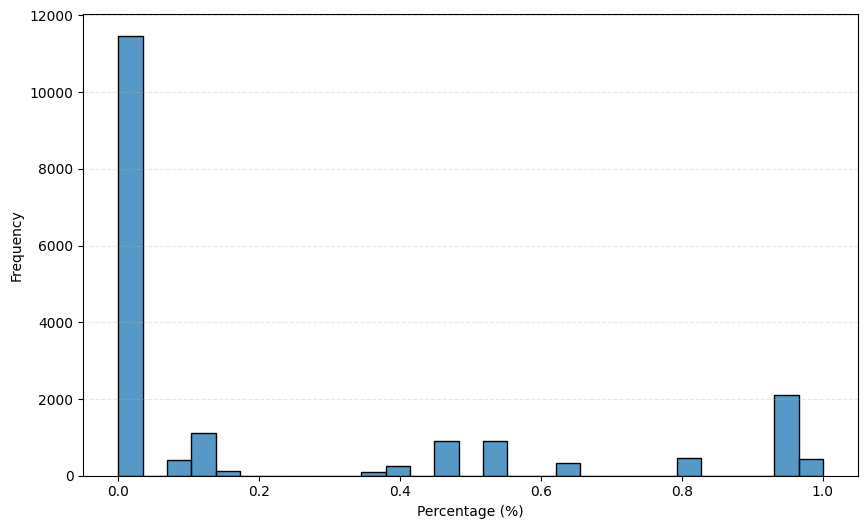

```python
import matplotlib.pyplot as plt
import seaborn as sns


# Set up the figure and axis
plt.figure(figsize=(10, 6))

# Create a histogram
sns.histplot(probs_distribution, kde=False)  # Adjust bins as needed

# Add labels and title
plt.xlabel('Percentage (%)')
plt.ylabel('Frequency')
#plt.title('Distribution of Percentages')

# Show grid lines for better readability
plt.grid(axis='y', linestyle='--', alpha=0.3)

#plt.gca().patch.set_alpha(0)
#plt.savefig("distribution_of_percentages.svg", format="svg", transparent=True)

plt.show()
```

agora a ideia seria ao invés de ter 0.4999 = 0 e 0.5000 = 1, fazer um intervalo

do tipo:

- < 0.4 - lixo
- 0.4 a 0.6 - selecionar frases que contêm alias
- > 0.6, manter noticia toda

```python
set(probs_distribution)
```

```
{0.0,
 0.021,
 0.1,
 0.118,
 0.133,
 0.143,
 0.375,
 0.4,
 0.467,
 0.533,
 0.625,
 0.818,
 0.933,
 1.0}
```